# Spatial Data Analysis (450:320)

Class 2

The code behind the title page map:

```r
library(ggmap) # NOTE: you need to set up an API key to use Google Maps
m <- get_googlemap(center = c(-74.435018, 40.521089), zoom = 17,
                   maptype = "hybrid")
ggmap(m, extent = "device")
```

## Class overview

- Installation progress (trouble shooting)/Class resources
- R and RStudio
- Your class `R` package!
- `git` / GitHub
- Start to use R Markdown

We have **5** big tasks today, so please follow along closely.

## Class resources

In general, you will only need your own computer(s) for this class. However, you also have access to the following spaces:

- **Classroom B266**
  - The class schedule is posted outside the room or [online](https://geography.rutgers.edu/academics/undergraduate-program/teaching-lab-schedule-b266).
  - You may use the room when no class is scheduled (before 4PM).
- **Lab space B235**
  - All students in this class have access to this lab (use **RU ID**).
  - The lab is available for use at any time.
- All computers in both rooms are all set. The only step you may need is to install the required `R` packages.

## Class resources

Once you are comfortable with **Git/GitHub**, you can:

1. simply show up and work directly on a lab computer,
2. push your work to GitHub when finished,
3. and later pull everything onto your own computer(s).

I personally really enjoy this part. It feels like two versions of you are working in parallel spaces.

**Today**, we will meet **Git/GitHub**, your future best friend for not losing work!

## History of R

R is a relatively young language:

- *1992*: **R**obert Gentleman and **R**oss Ihaka started to develop R as a research project.
- *1995*: Convinced by Martin Maechler, R became **open-source** under GPL2 license.
- *1997 - 2000*: A critical stage for early development, including R core group, CRAN, and r-project.org.
- *2000*: **R 1.0.0** was released at February 29.

## R system

[figure not shown]

## R system

Let’s get back to this code chunk:

```r
# Load libraries
library(terra) # library is a function from base R

# Query DEM data for Colombia
# elevation_30s is a function from R package geodata
col_dem <- geodata::elevation_30s(country = "COL", res = 10, path = tempdir())

# Plot the map to a png file
# plot is a special function, which we call as generic function in R.
plot(col_dem, axes = FALSE, box = FALSE)
```

## RStudio

It is an **Integrated Development Environment (IDE)**. It was originally designed for `R`, but now also supports others, such as Python.

An IDE acts like a “smart home” for coding. For example:

- `R` is the language (like English, Chinese, Spanish, etc).
- `RStudio` is like the Google Doc or Microsoft Word.

*Let’s take a quick look at R and RStudio to get a better sense of them.*

## Your `R` package!

Let’s work together to create your first-ever `R` package for this class.

- Set up a working directory, e.g.
  - `c:\My Documents\courses` (Windows)
  - `/Users/you/courses` (macOS).

Make sure you remember where it is.

- Install `R` package `devtools`:
  - Run `install.packages("devtools")` in Console
  - Or install it from Packages tab in RStudio.
- Type **1** in the Chat if you’ve done these two steps.

## Your `R` package!

- Create an R package (let me show you first)
- Type **2** in the Chat if you’ve created the package.

## Version control

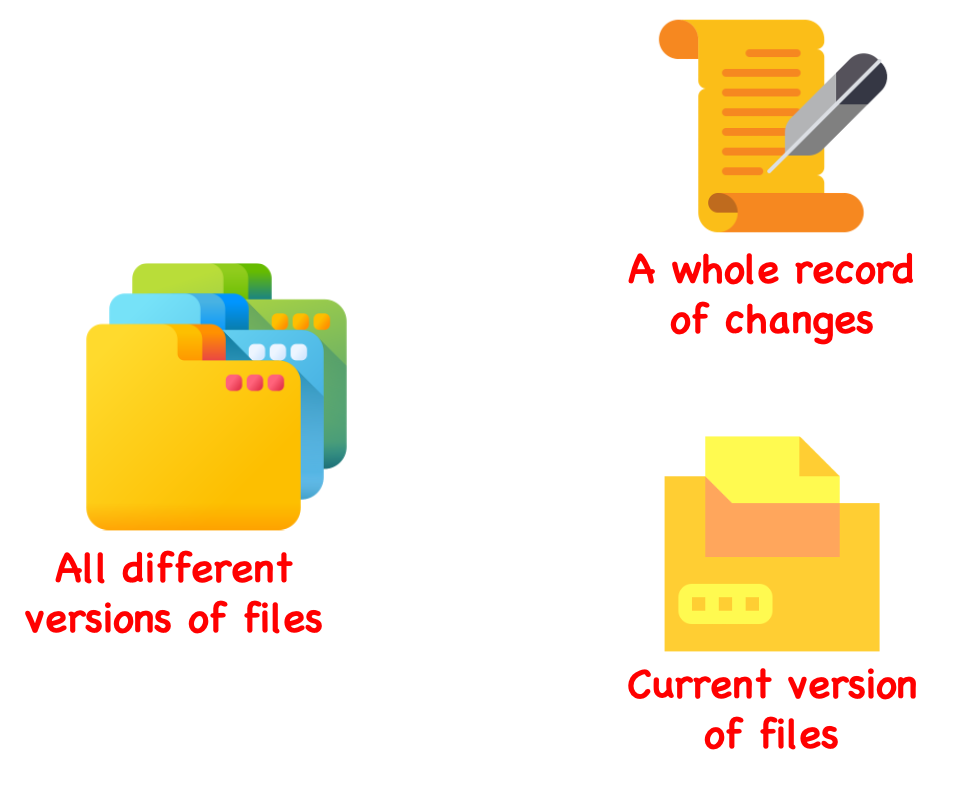

## Git and local environment

Version control is the idea, and `Git` is the actual machine to do it.

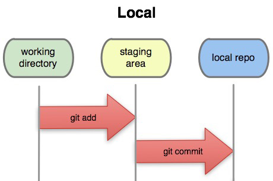

- `git add`: you pick the good parts and put them in a staging area.
- `git commit`: you snap the photo and file it away.

## Fun time

`git add` and `git commit` your updates on your own package.

- Type **3** in the Chat if you’ve done!

## Fun time

- Let’s make some changes to the package DESCRIPTION:

```
Package: ls320
Type: Package
Title: What the Package Does (Title Case)
Version: 0.1.0
Authors@R: c(
    person(
      "Jane", "Doe",
      email = "jane@example.com",
      role = c("aut", "cre")
    )
  )
Description: More about what it does (maybe more than one line).
    Continuation lines should be indented.
```

- Replace the **entire** `Authors@R` lines with two new lines:

```
Author: Your Name
Maintainer: Your Name <your.email@domain.com>
```

- Update Title and Description.
- then `git add` and `git commit` your changes
- Type **4** in the Chat if you’ve done!

## Git and GitHub

- The package on your local machine is the local repo
- GitHub is the remote repo

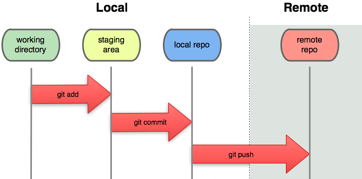

## Remote repo on GitHub

- You should have already set up your GitHub account and SSH.
- Go to either your personal GitHub account or SSELP
  - It is easier for me to monitor your work if you create the repo under SSELP
  - But the choice is entirely up to you.
- Create a new **private** repo (let me show you first)

## Link local repo to remote repo on GitHub

- Run what you have been told on GitHub
- Run `git push origin main` in terminal or hit the **Push** button in Git tab.
- Type **5** in the Chat if you can see everything on your remote repo!
- Invite me and Arafat as the collaborator for your repo (**!!**)
  - Only after you do this, will we be able to access your repo.

## Class notes (Highly recommended)

- You can create a folder, for example, named as “docs” or “notes” within your class package.
- Organize all your class notes in this folder using **R Markdown**.

## R Markdown

One of the many benefits of using RStudio is that it makes writing R Markdown convenient. But **why** R Markdown?

- Has an accessible learning curve (rich text syntax)
- Integrate R code directly into writing
  - Reproducibility!
- Offers many output formats (HTML, PDF, Word, etc.)

## R Markdown

[figure not shown]

## R Markdown

### Syntax

Let’s run a demo together to learn the syntax (if have time).

More details can go [here](https://bookdown.org/yihui/rmarkdown/html-document.html).

## Homework

- Make sure your package is alive locally and remotely.
- Invite me and Arafat as the collaborator for your repo.
- Read and try the [rmarkdown_demo](https://sselp.github.io/sdawr//rmarkdown_demo.Rmd). The knitted html is like [this](https://sselp.github.io/sdawr//rmarkdown_demo.html).
- Read **Section 1-2** in **Unit 1, Module 2**.